# Impact of Severe Weather Events in the United States

Ben Sylve

8/17/2020

## Synosis

This analysis is intended to provide an overview of the impact of sever weather events in the United States. Impact was assessed by looking at the impact on population health and economic consequences. Population health was assessed by reviewing the number of fatalities per weather event type while economic consequences was assessed by reviewing the combined property and crop damage cost. The top 10 event types since the year 2000 for number of fatalities and economic consequences are provided in the figures to follow. More recent data was chosen to reflect recent weather patterns and to take advantage of the completeness of recent data sets.

## Data Processing

Data processesing occurs in the following manner:

1 - Download the storm data from the web

2 - Reduce the dataset to focus on the year 2000 and later

4 - Summarize the top 10 event types by fatality count

```r
# Load the dplyr package used to summarize the data
library(dplyr)
```

```r
# Load the ggplot2 package used to graph the data
library(ggplot2)
# Code to format ggplot2 axes
library(scales)
```

```r
# STEP 1

# Read the csv data and store it as a tables
download.file("https://d396qusza40orc.cloudfront.net/repdata%2Fdata%2FStormData.csv.bz2","stormdata.scv.bz2")
stormData <- read.csv("stormdata.scv.bz2", stringsAsFactors = FALSE)
stormDataTable <- as_tibble(stormData, stringsAsFactors = FALSE)
rm("stormData")
stormDataTable$BGN_DATE_DTM <- as.Date(substr(stormDataTable$BGN_DATE,1,which(strsplit(stormDataTable$BGN_DATE, "")[[1]]==" ")), format='%m/%d/%Y')
```

```r
# STEP 2

# Get events since 2000 because the data is more complete
stormDataTableSince2000 <- stormDataTable %>% filter(BGN_DATE_DTM >= "2000-01-01")

# STEP 3

# Get the property damage dollars per event
stormDataTableSince2000$PRODMGMULTIPLYER <- ifelse(stormDataTableSince2000$PROPDMGEXP=="K",1000,ifelse(stormDataTableSince2000$PROPDMGEXP=="M",1000000,ifelse(stormDataTableSince2000$PROPDMGEXP=="B",1000000000,1)))
stormDataTableSince2000$PROPDMGALL <- stormDataTableSince2000$PRODMGMULTIPLYER * stormDataTableSince2000$PROPDMG

# Get the crop damage dollars per event
stormDataTableSince2000$CROPDMGMULTIPLYER <- ifelse(stormDataTableSince2000$CROPDMGEXP=="K",1000,ifelse(stormDataTableSince2000$CROPDMGEXP=="M",1000000,ifelse(stormDataTableSince2000$CROPDMGEXP=="B",1000000000,1)))
stormDataTableSince2000$CROPDMGALL <- stormDataTableSince2000$CROPDMGMULTIPLYER * stormDataTableSince2000$PROPDMG

# Summarize all dollars per event
stormDataTableSince2000$DMGALL <- stormDataTableSince2000$CROPDMGALL + stormDataTableSince2000$PROPDMGALL

# STEP 4

# Summarize the impact by event type
stormDataSummaryTopFatalities <- stormDataTableSince2000 %>% group_by(EVTYPE) %>% summarize(FATALITIES = sum(FATALITIES), INJURIES = sum(INJURIES), DAMAGE = sum(DMGALL)) %>% slice_max(order_by = FATALITIES, n = 10)
# STEP 5

# Summarize the impact by economics
stormDataSummaryTopDollars <- stormDataTableSince2000 %>% group_by(EVTYPE) %>% summarize(FATALITIES = sum(FATALITIES), INJURIES = sum(INJURIES), DAMAGE = sum(DMGALL)/1000000000) %>% slice_max(order_by = DAMAGE, n = 10)
```

## Results

Tornadoes have the most impact on population health in terms of fatalities.

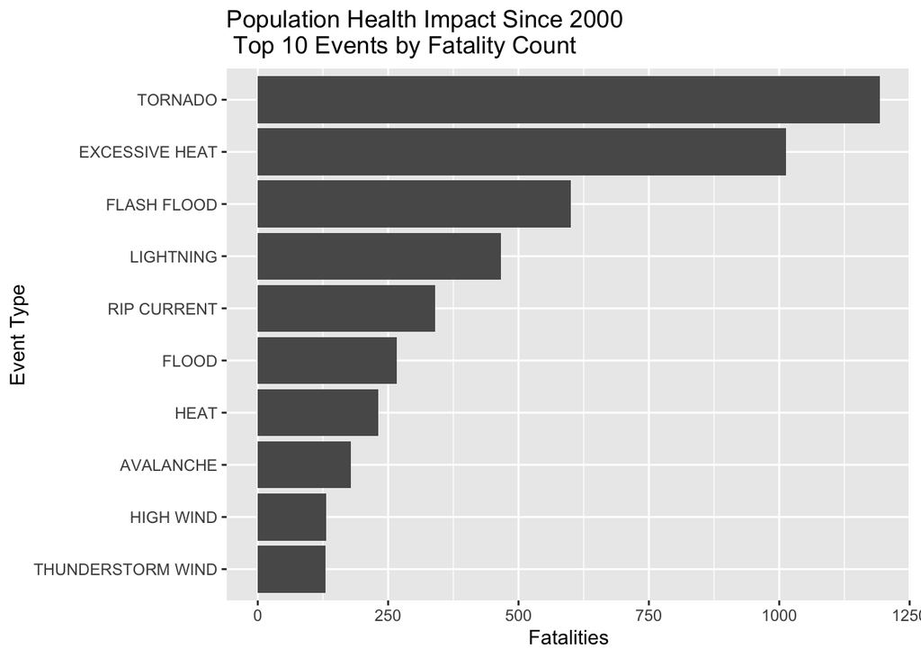

```r
# Plot the results for impact on lives
ggplot(data=stormDataSummaryTopFatalities, aes(x=reorder(EVTYPE, FATALITIES), y=FATALITIES), group=1) + labs(x="Event Type", y="Fatalities") + geom_bar(stat="identity") + coord_flip() + ggtitle("Population Health Impact Since 2000 \n Top 10 Events by Fatality Count")
```

Floods have the most economic consequences.

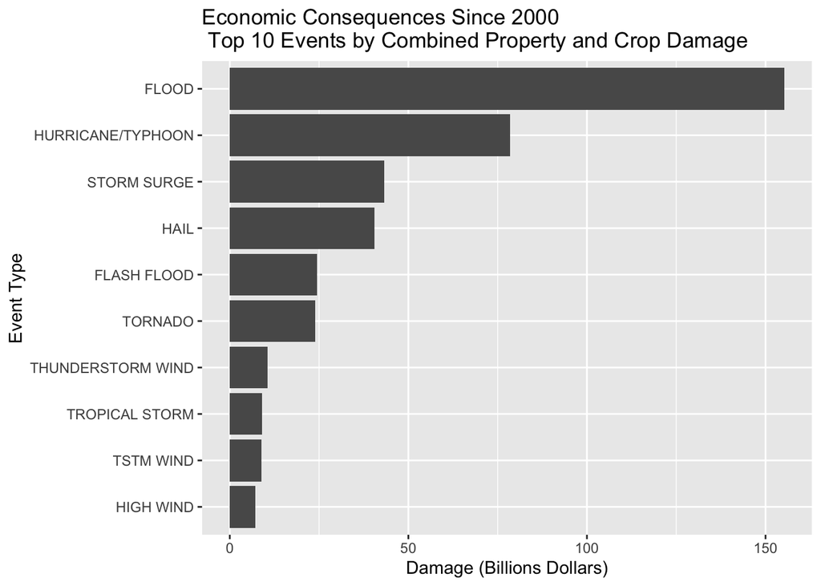

```r
# Plot the results for impact on economics
ggplot(data=stormDataSummaryTopDollars, aes(x=reorder(EVTYPE, DAMAGE), y=DAMAGE), group=1) + labs(x="Event Type", y="Damage (Billions Dollars)") + geom_bar(stat="identity") + coord_flip() + scale_y_continuous(labels=comma) + ggtitle("Economic Consequences Since 2000 \n Top 10 Events by Combined Property and Crop Damage")
```